# Short-term forgetting in sentence comprehension: Crosslinguistic evidence from verb-ﬁnal structures

## 5. Experiment 3

Experiment 3 was an SPR study on German double center-embedding constructions. Consider example (3).

1. Der Anwalt, den der Zeuge, den der Spion betrachtete, schnitt, $überzeugte_{_{V1}}$ den Richter.
2. Der Anwalt, den der Säbel, den der Spion betrachtete, schnitt, $überzeugte_{_{V1}}$ den Richter.
3. Der Anwalt, den der Zeuge, den der Spion betrachtete, – $überzeugte_{_{V1}}$ den Richter.
4. Der Anwalt, den der Säbel, den der Spion betrachtete, – $überzeugte_{_{V1}}$ den Richter.

*VP-forgetting hypothesis* predicts that Grammatical conditions would have slower processing times compared to ungrammatical consitions where a middle VP is missing. In particular, a slowdown is expected at V1 and postV1 in condition 3-a and 3-b compared to condition 3-c and 3-d.

In addition, I also test the effect of interference. 3-a and 3-c are high-interference conditions and 3-b and 3-d are low-interference conditions. Because high-memory load in high-interference condition, *VP-forgetting hypothesis* would predict larger effect of grammaticality in high-interference condition – such that difference in reading times between grammatical and ungrammatical condition is higher in high-interference condition compared to low-interference condition.

**Note that in the paper, the authors test the effect of grammaticality only.**

### 5.1 Load the data

```
##   subject  expt item condition position            word measure value  roi gram
## 1      10 inter   10         c        1    Der_Pianist,      rt   957  NP1   -1
## 2      10 inter   10         c        2             den      rt   823  who   -1
## 3      10 inter   10         c        3    der_Cellist,      rt  1456  NP2   -1
## 4      10 inter   10         c        4             den      rt  1057 that   -1
## 5      10 inter   10         c        5 der_Hausmeister      rt  1415  NP3   -1
## 6      10 inter   10         c        6            sah,      rt  5438   V3   -1
##   intf
## 1    1
## 2    1
## 3    1
## 4    1
## 5    1
## 6    1
```

### 5.2 Visualize the data

#### 5.2.1 Mean and Confidence interval in grammatical vs. Ungrammatical conditions

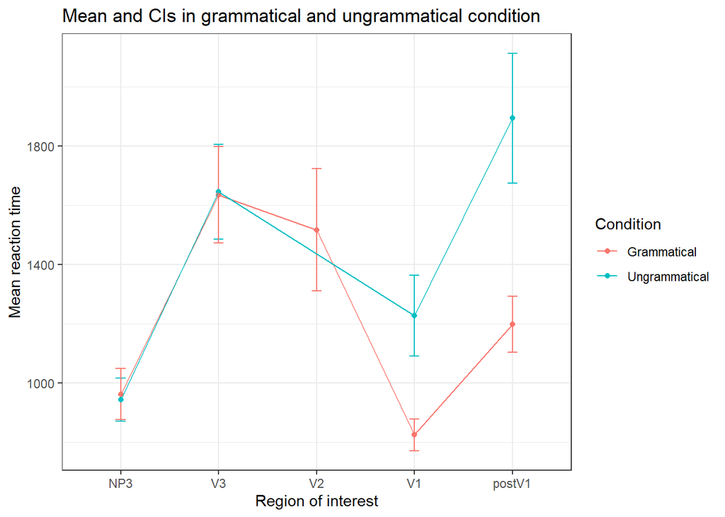

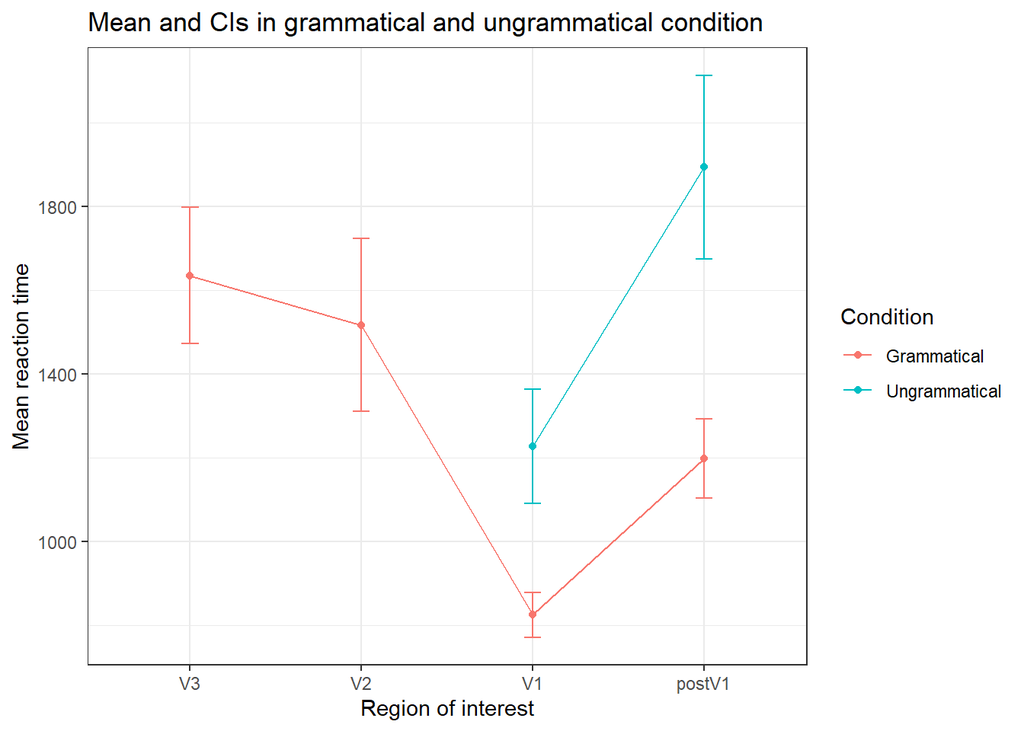

**The plot shows slow-down in ungrammatical conditions. This will be tested formally using a mixed-effect linear model**

#### 5.2.2 Mean and Confidence interval in high vs. low interference conditions

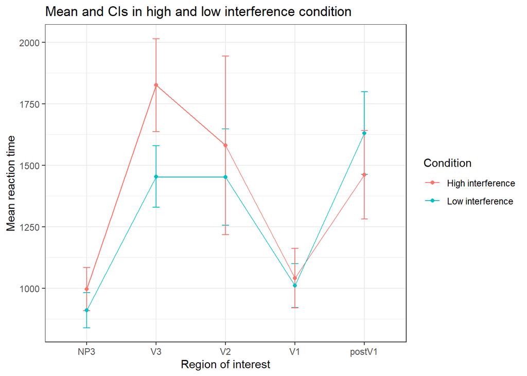

#### 5.2.3 Visualize by-subject data

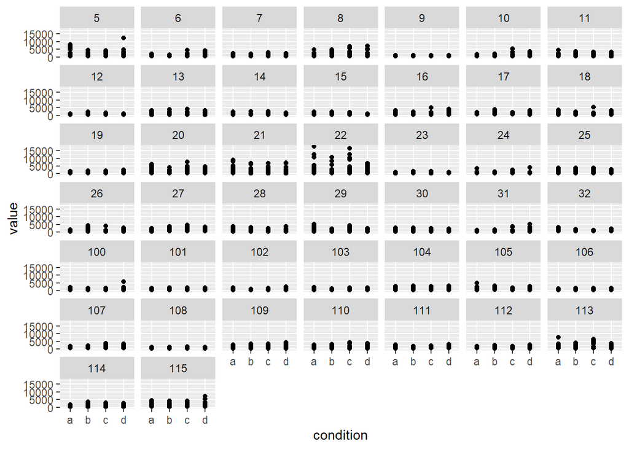

#### 5.2.3 Visualize by-item data

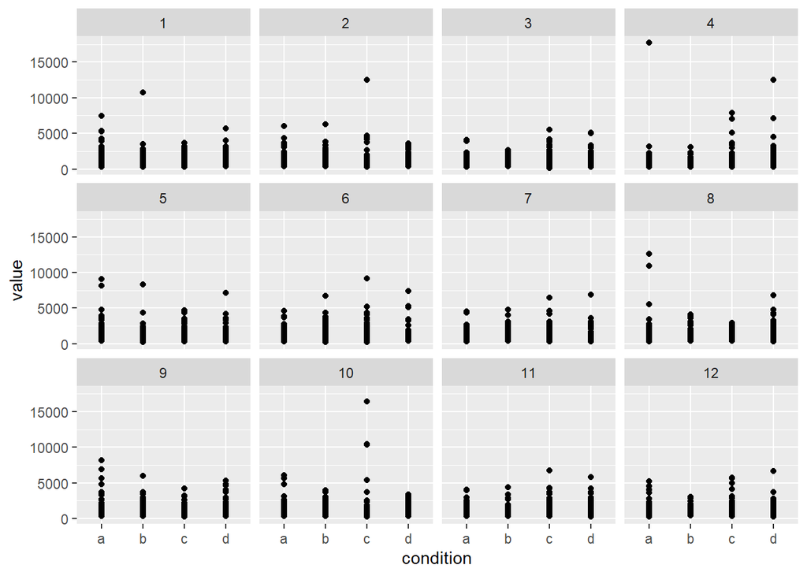

### 5.3 Analysis with linear mixed-effect models

#### 5.3.1 at V1: interaction effect (grammaticality x interference)

The model and the predictions are same as in experiment 1 (see section 2.3.1).

**Results**

```r
data.V1 <- subset(data.m,roi=='V1')
mod.e1.1 <- lmer(log(value)~gram*intf+(1+gram*intf|subject)+(1+gram*intf|item),data=data.V1, control=lmerControl(optimizer="optimx",optCtrl=list(method='nlminb')))
#save(mod.e1.1,'models/E1_V1_gramxintf.Rda')
```

1. Fixed effect estimates

```r
apa_table(
  as.data.frame(summary(mod.e1.1)$coefficients)
  , caption = "Estimated effect of grammaticality and interference at V1 region"
  , escape = FALSE
)
```

(#tab:unnamed-chunk-48)

*Estimated effect of grammaticality and interference at V1 region*

|  | Estimate | Std. Error | t value |
| --- | --- | --- | --- |
| (Intercept) | 6.75 | 0.05 | 142.72 |
| gram | -0.13 | 0.04 | -3.56 |
| intf | -0.01 | 0.02 | -0.45 |
| gram:intf | 0.02 | 0.02 | 0.85 |

**VP-forgetting hypothesis predicted positive sign for the effect of grammaticality. But we get a negative sign here, suggesting that grammatical conditions are faster than ungrammatical conditions where a middle VP is missing.**

2. Residuals

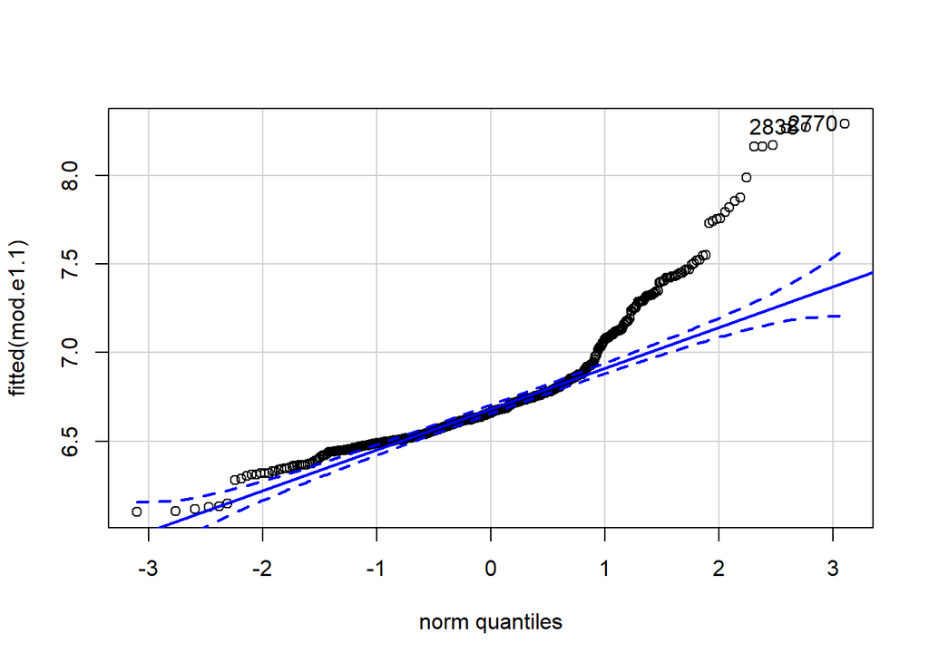

```
## 2770 2838
##  326  334
```

```r
# Let's check the residuals
qqPlot(fitted(mod.e1.1))
```

3. Participant-level differences

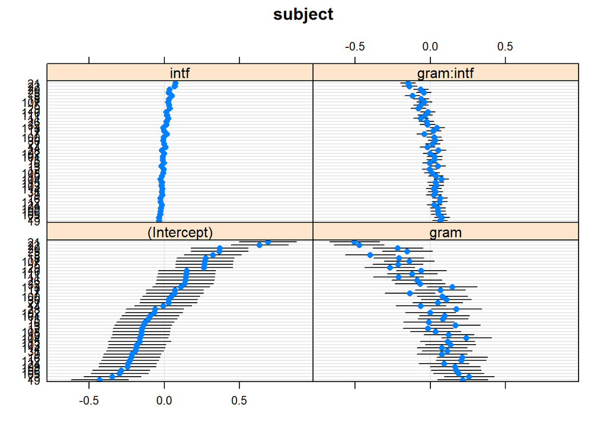

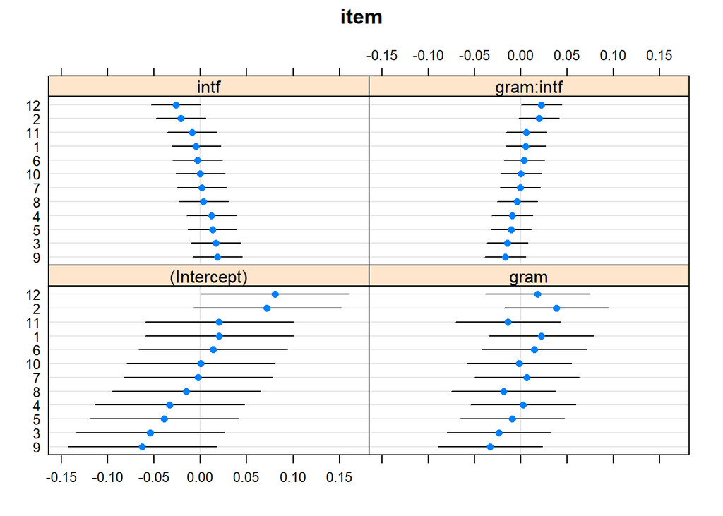

```r
print(dotplot(ranef(mod.e1.1,condVar=TRUE)))
```

#### 5.3.2 at postV1: interaction effect (grammaticality x interference)

$\textbf{Results:}$

```r
data.postV1 <- subset(data.m,roi=='postV1')
mod.e1.3 <- lmer(log(value)~gram*intf+(1+gram*intf|subject)+(1+gram*intf|item),data=data.postV1, control=lmerControl(optimizer="optimx",optCtrl=list(method='nlminb')))
#save(mod.e1.3,'models/E1_postV1_gramxintf.Rda')
```

1. Fixed effect estimates

```r
apa_table(
  as.data.frame(summary(mod.e1.3)$coefficients)
  , caption = "Estimated effect of grammaticality and interference at post V1 region"
  , escape = FALSE
)
```

(#tab:modelE1.3_coeff)

*Estimated effect of grammaticality and interference at post V1 region*

|  | Estimate | Std. Error | t value |
| --- | --- | --- | --- |
| (Intercept) | 7.12 | 0.06 | 119.86 |
| gram | -0.18 | 0.03 | -5.91 |
| intf | -0.06 | 0.02 | -2.42 |
| gram:intf | 0.02 | 0.03 | 0.82 |

2. Residuals

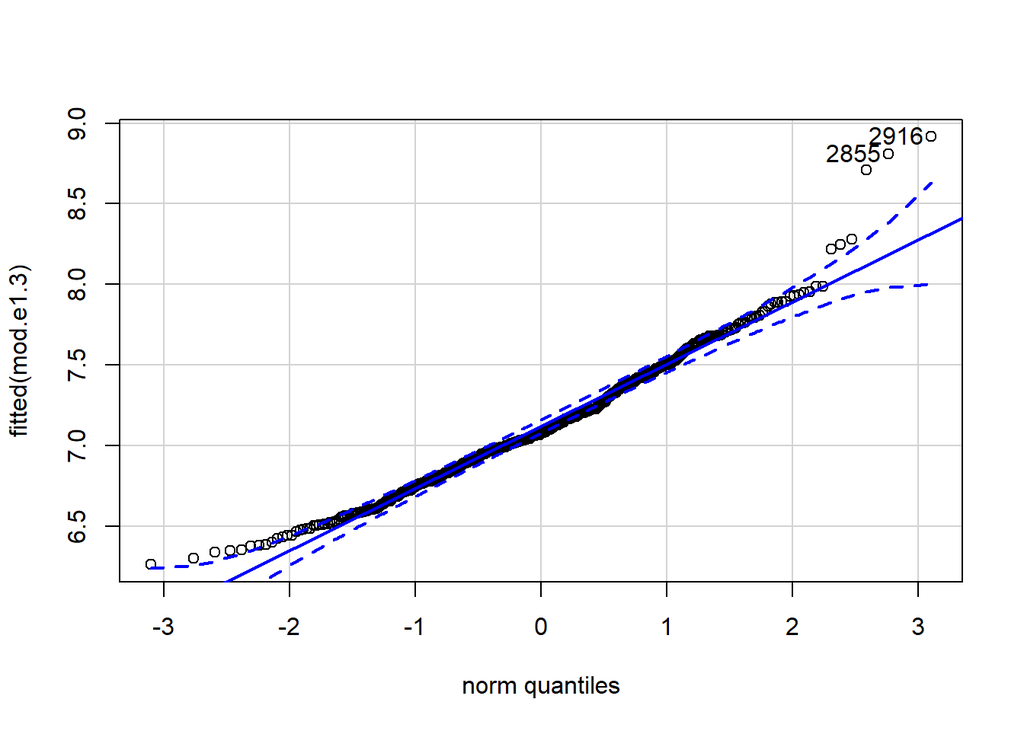

```
## 2916 2855
##  343  336
```

```r
# Let's check the residuals
qqPlot(fitted(mod.e1.3))
```

3. Participant-level differences

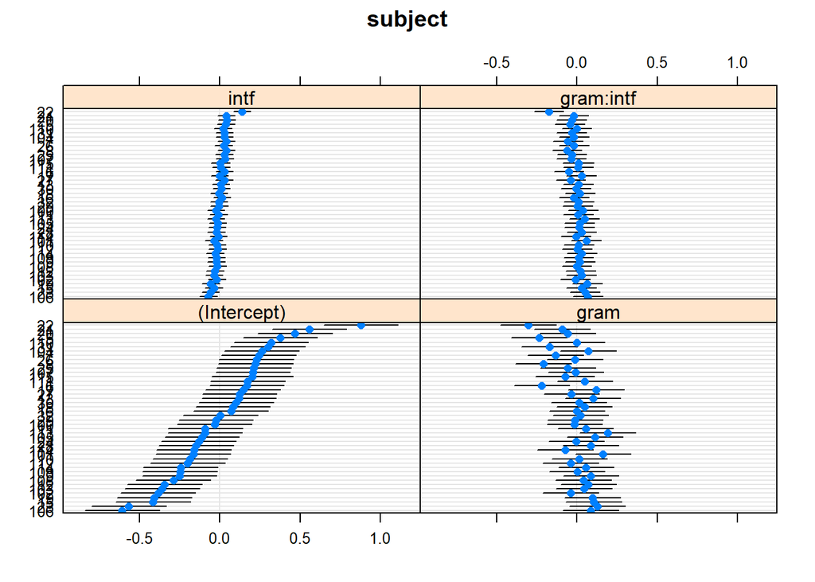

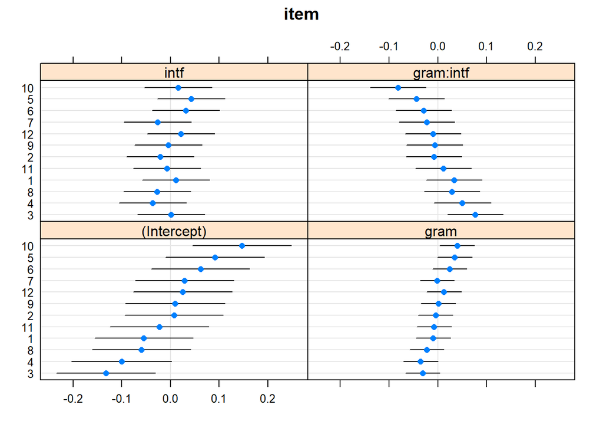

```r
print(dotplot(ranef(mod.e1.3,condVar=TRUE)))
```

### 5.4 Summary of Experiment 3

- Main effect of grammaticality at V1 and postV1 region such that grammatical conditions have faster processing times than ungrammatical conditions, where a VP was missing (counter-evidence for VP-forgetting hypothesis i.e., German speakers apparently tend to not forget the predicted middle verb-phrase node).
- No interaction effect between grammaticality and interference

## 6. Experiment 4

### 6.1 Load the data

```
##       subject trial version response roi condition c1 c2 itemnum times    value
## 36721      46    63       1        1   1         a -1 -1       1   RRT   21.002
## 36722      35    63       1        1   5         a -1 -1       1   RRT  168.108
## 36723     104    63       1        0  11         a -1 -1       1   RRT  109.291
## 36725      50    63       1        1   9         a -1 -1       1   RRT  634.644
## 36726      42    63       1        1  11         a -1 -1       1   RRT  731.361
## 36727      31    63       1        1   9         a -1 -1       1   RRT 1676.968
##       gram intf region
## 36721    1    1    NP1
## 36722    1    1    NP3
## 36723    1    1     V1
## 36725    1    1     V3
## 36726    1    1     V1
## 36727    1    1     V3
```

### 6.2 Visualize the data

#### 6.2.1 Mean and Confidence interval in grammatical vs. Ungrammatical conditions

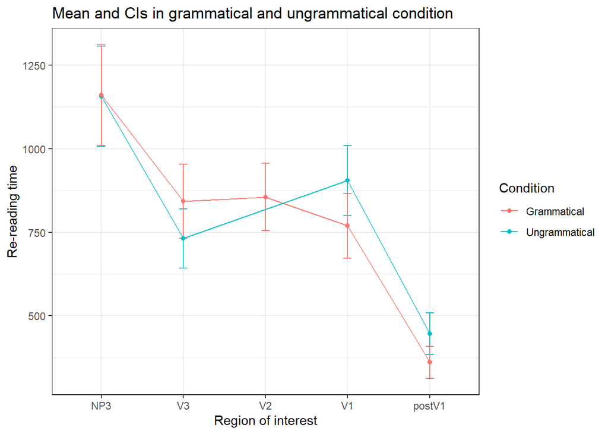

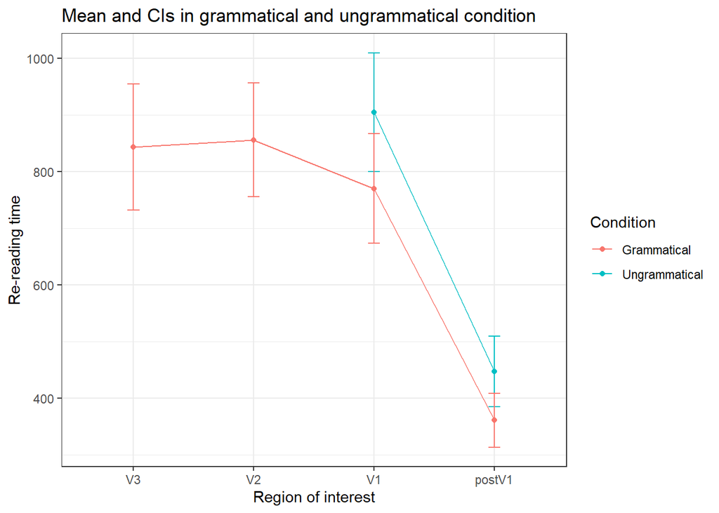

#### 6.2.2 Mean and Confidence interval in high vs. low interference conditions

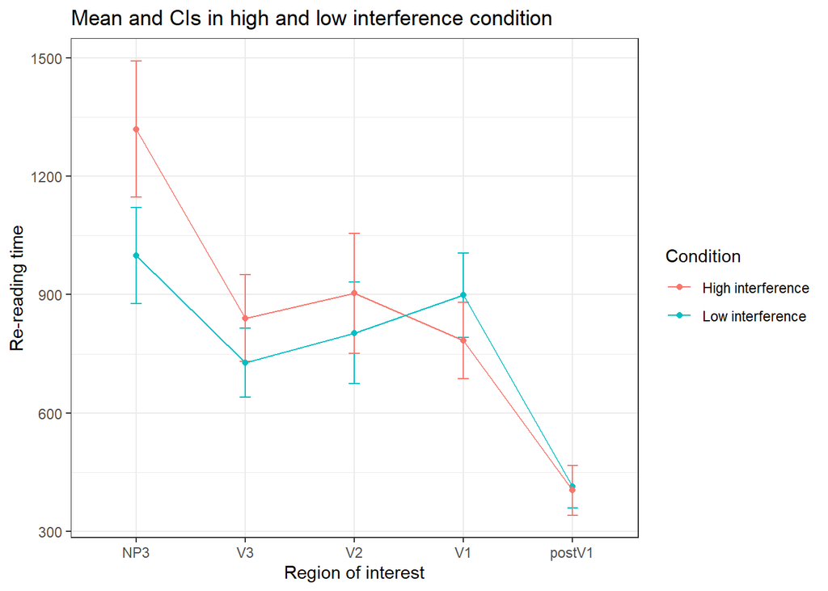

#### 6.2.3 Visualize by-subject data

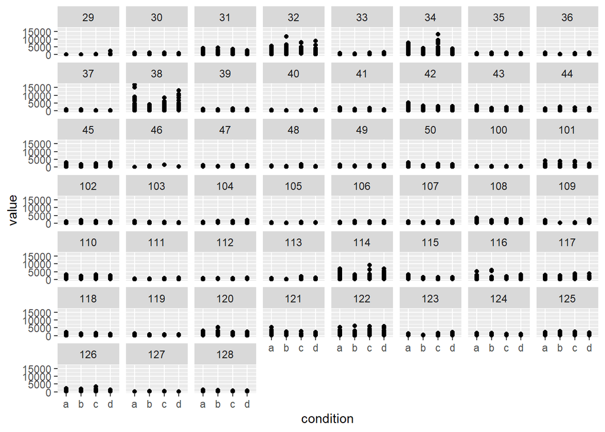

#### 6.2.4 Visualize by-item data

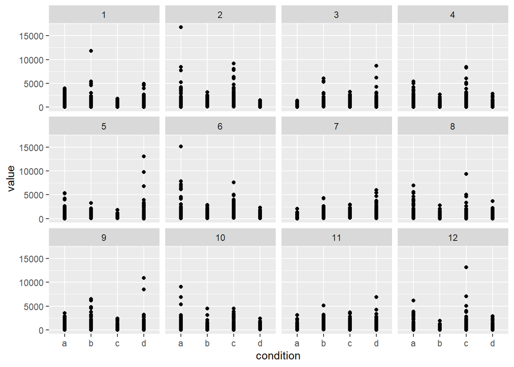

### 6.3 Analysis with linear mixed-effect models

#### 6.3.1 at V1: interaction effect (grammaticality x interference)

**However, re-reading time (RRT) has been used as dependent variable here (see the paper for more details).**

**Results**

```r
data.V1 <- subset(data.m,region=='V1')
mod.e1.1 <- lmer(log(value)~gram*intf+(1+gram*intf|subject)+(1+gram*intf|itemnum),data=data.V1, control=lmerControl(optimizer="optimx",optCtrl=list(method='nlminb')))
#save(mod.e1.1,'models/E1_V1_gramxintf.Rda')
```

1. Fixed effect estimates

```r
apa_table(
  as.data.frame(summary(mod.e1.1)$coefficients)
  , caption = "Estimated effect of grammaticality and interference at V1 region"
  , escape = FALSE
)
```

(#tab:unnamed-chunk-58)

*Estimated effect of grammaticality and interference at V1 region*

|  | Estimate | Std. Error | t value |
| --- | --- | --- | --- |
| (Intercept) | 6.24 | 0.09 | 67.17 |
| gram | -0.09 | 0.04 | -2.14 |
| intf | -0.13 | 0.05 | -2.64 |
| gram:intf | 0.09 | 0.05 | 1.86 |

**There is a main effect of grammaticality at V1 region.**

2. Residuals

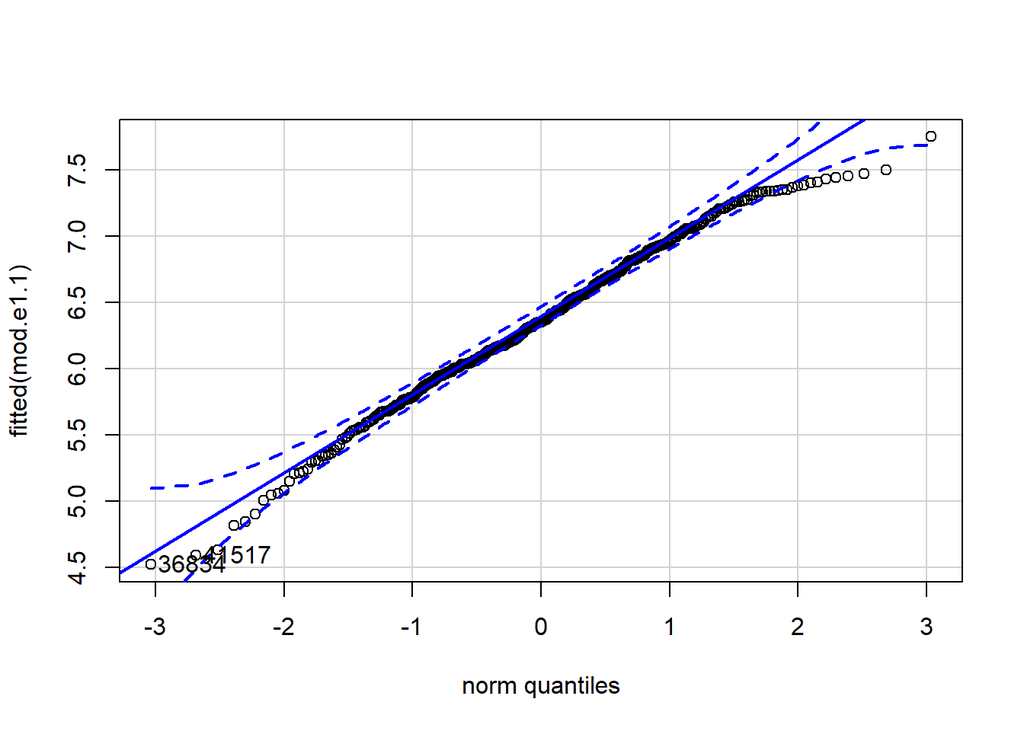

```
## 36834 41517
##     7   319
```

```r
# Let's check the residuals
qqPlot(fitted(mod.e1.1))
```

3. Participant-level differences

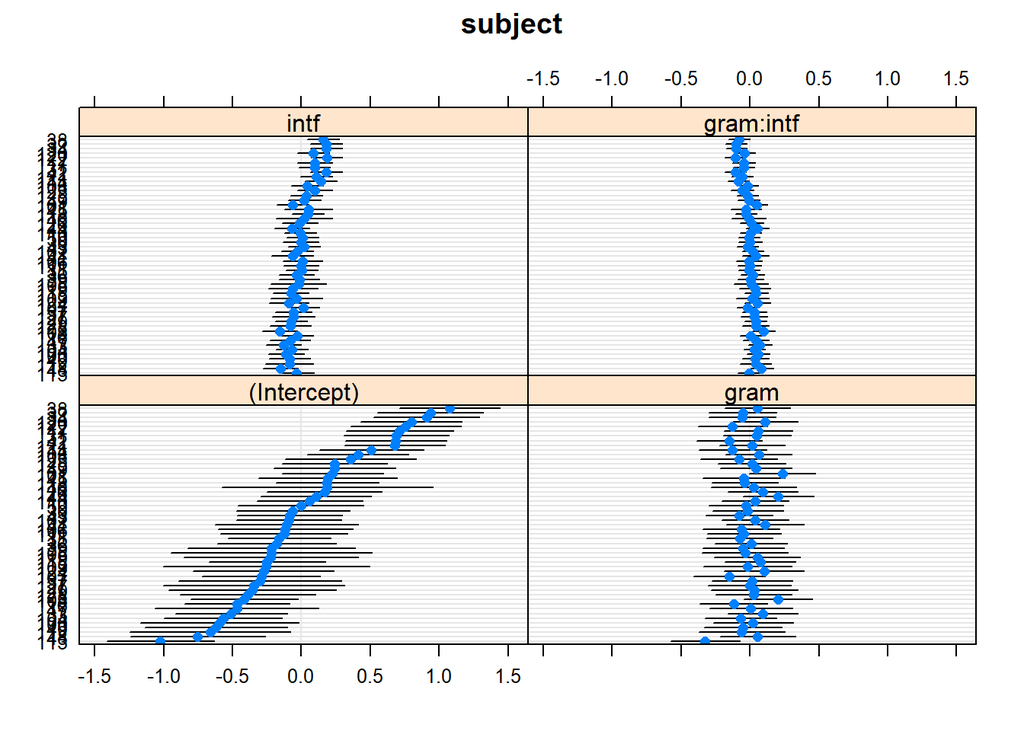

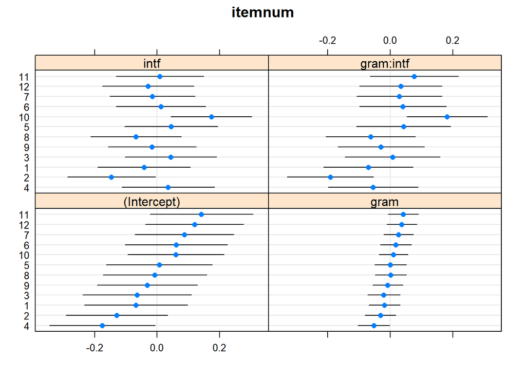

```r
print(dotplot(ranef(mod.e1.1,condVar=TRUE)))
```

#### 6.3.2 at postV1: interaction effect (grammaticality x interference)

$\textbf{Results:}$

```r
data.postV1 <- subset(data.m,region=='postV1')
mod.e1.3 <- lmer(log(value)~gram*intf+(1+gram*intf|subject)+(1+gram*intf|itemnum),data=data.postV1, control=lmerControl(optimizer="optimx",optCtrl=list(method='nlminb')))
#save(mod.e1.3,'models/E1_postV1_gramxintf.Rda')
```

1. Fixed effect estimates

```r
apa_table(
  as.data.frame(summary(mod.e1.3)$coefficients)
  , caption = "Estimated effect of grammaticality and interference at post V1 region"
  , escape = FALSE
)
```

(#tab:unnamed-chunk-62)

*Estimated effect of grammaticality and interference at post V1 region*

|  | Estimate | Std. Error | t value |
| --- | --- | --- | --- |
| (Intercept) | 5.60 | 0.09 | 63.98 |
| gram | -0.07 | 0.06 | -1.16 |
| intf | -0.09 | 0.07 | -1.30 |
| gram:intf | -0.01 | 0.08 | -0.09 |

2. Residuals

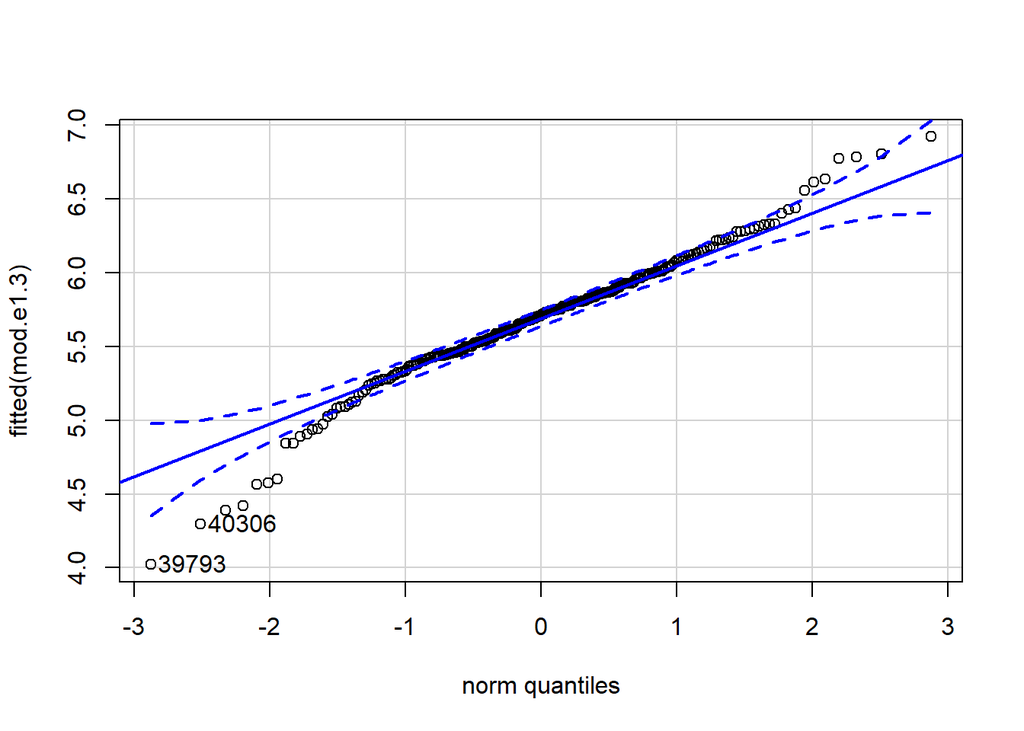

```
## 39793 40306
##   112   140
```

```r
# Let's check the residuals
qqPlot(fitted(mod.e1.3))
```

3. Participant-level differences

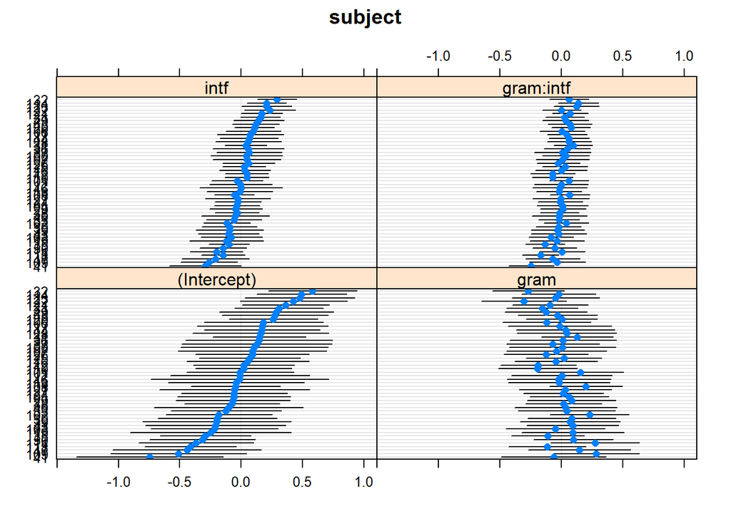

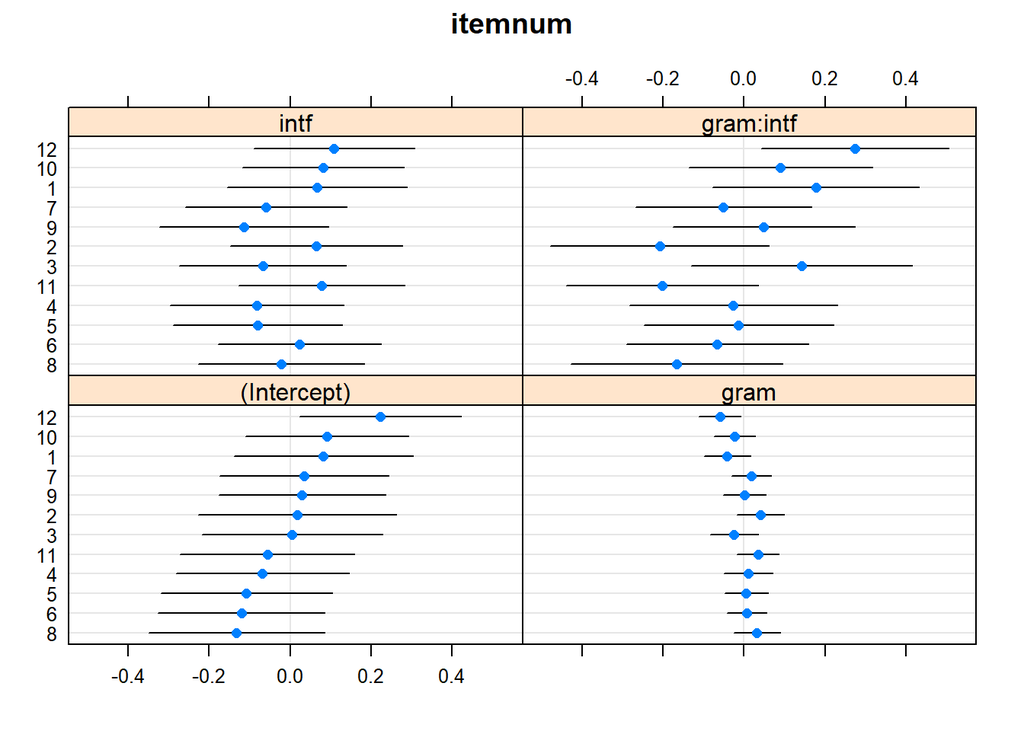

```r
print(dotplot(ranef(mod.e1.3,condVar=TRUE)))
```

### 6.4 Summary of Experiment 4

- Main effect of grammaticality at V1 region such that grammatical conditions have faster processing times than ungrammatical conditions, where a VP was missing (counter-evidence for VP-forgetting hypothesis i.e., German speakers apparently tend to not forget the predicted middle verb-phrase node).
- No effect of grammaticality at postV1 region.

## 7. Experiment 5

Experiment 5 was an SPR study on English double center-embedding constructions. The stimuli were same as Experiment 1 with only difference that commas were added to the relative clauses. Consider example (4).

1. The carpenter, who the craftsman, that the peasant carried, hurt, $supervised_{_{V1}}$ the apprentice.
2. The carpenter, who the pillar, that the peasant carried, hurt, $supervised_{_{V1}}$ the apprentice.
3. *The carpenter, who the craftsman, that the peasant carried, – $supervised_{_{V1}}$ the apprentice.
4. *The carpenter, who the pillar, that the peasant carried, – $supervised_{_{V1}}$ the apprentice.

The predictions were same as in Experiment 1 (see section 2).

### 7.1 Load the data

```
##    subject expt item condition position     word measure value  roi gram intf
## 65       1  gug   14         b        1      The      rt   322  NP1    1   -1
## 66       1  gug   14         b        2 defence,      rt   348  NP1    1   -1
## 67       1  gug   14         b        3      who      rt  2705  who    1   -1
## 68       1  gug   14         b        4      the      rt   290  NP2    1   -1
## 69       1  gug   14         b        5   knife,      rt   267  NP2    1   -1
## 70       1  gug   14         b        6     that      rt   506 that    1   -1
```

### 7.2 Visualize the data

#### 7.2.1 Mean and Confidence interval in grammatical vs. Ungrammatical conditions

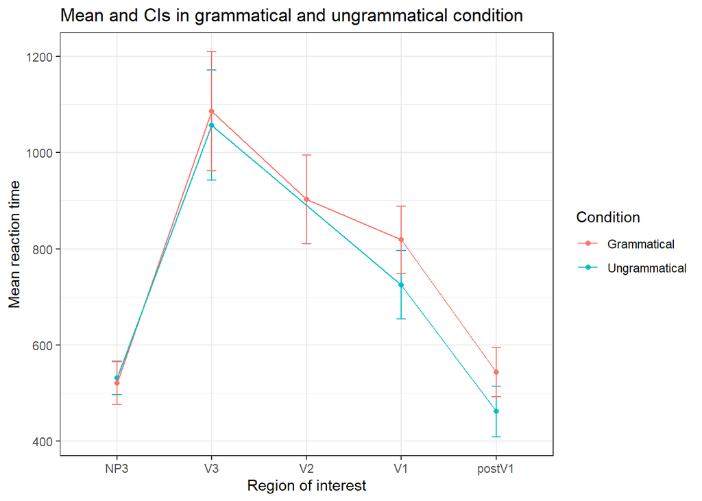

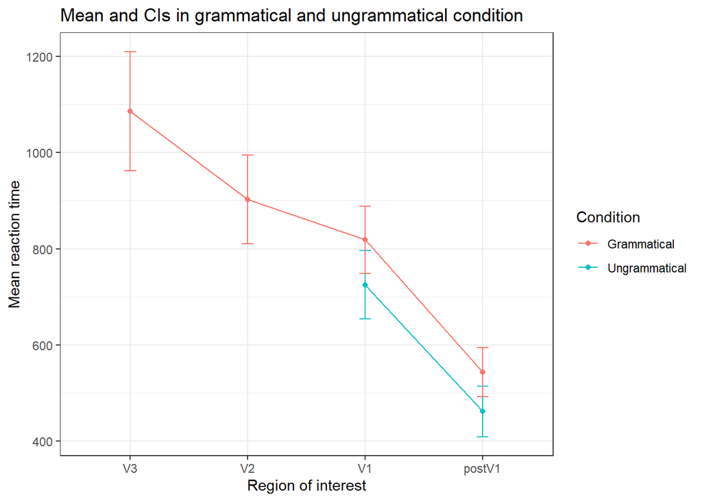

#### 7.2.2 Mean and Confidence interval in high vs. low interference conditions

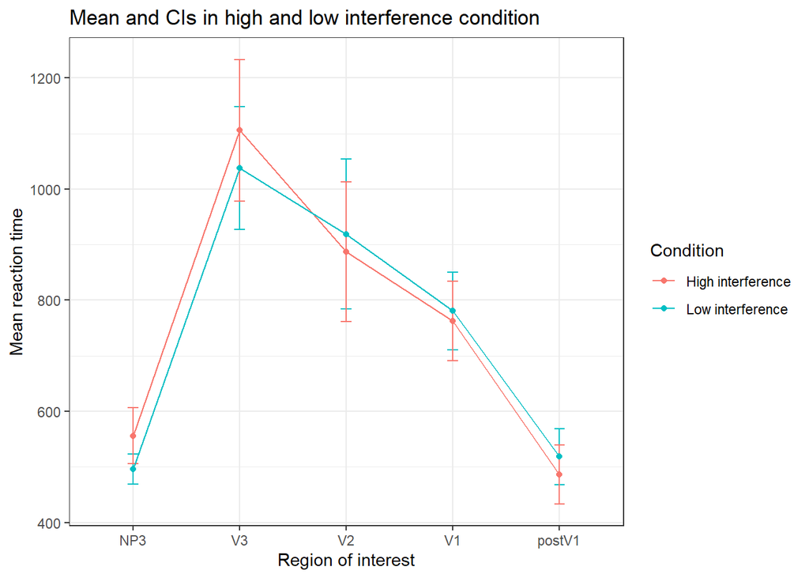

#### 7.2.3 Visualize by-subject data

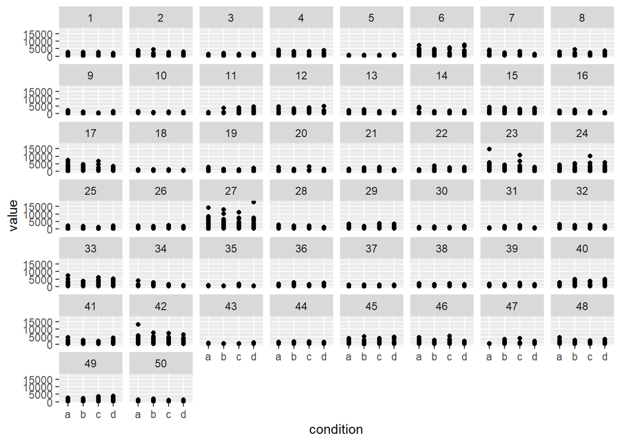

#### 7.2.4 Visualize by-item data

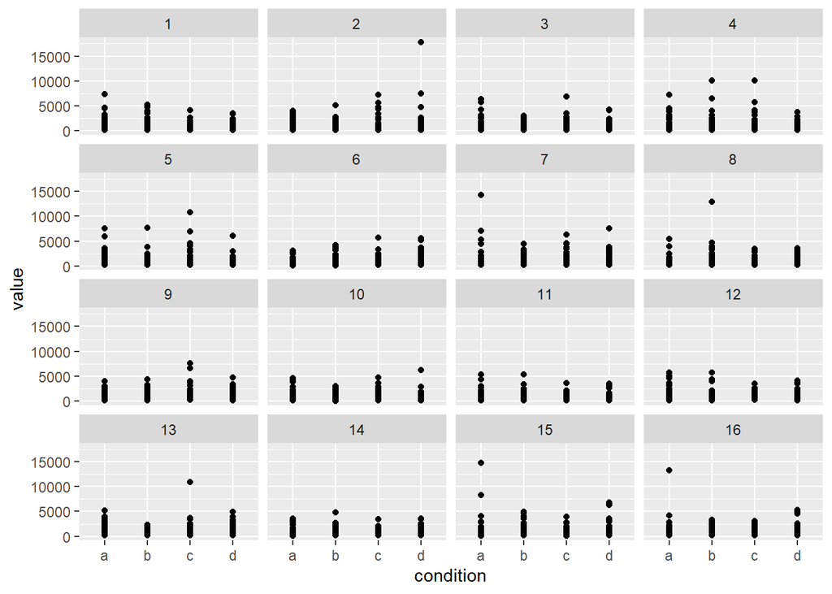

### 7.3 Analysis with linear mixed-effect models

#### 7.3.1 at V1: interaction effect (grammaticality x interference)

The model and the predictions are same as in Experiment 1 (see section 2.3.1).

**Results**

```r
data.V1 <- subset(data.m,roi=='V1')
mod.e1.1 <- lmer(log(value)~gram*intf+(1+gram*intf|subject)+(1+gram*intf|item),data=data.V1, control=lmerControl(optimizer="optimx",optCtrl=list(method='nlminb')))
#save(mod.e1.1,'models/E1_V1_gramxintf.Rda')
```

1. Fixed effect estimates

```r
apa_table(
  as.data.frame(summary(mod.e1.1)$coefficients)
  , caption = "Estimated effect of grammaticality and interference at V1 region"
  , escape = FALSE
)
```

(#tab:unnamed-chunk-72)

*Estimated effect of grammaticality and interference at V1 region*

|  | Estimate | Std. Error | t value |
| --- | --- | --- | --- |
| (Intercept) | 6.40 | 0.05 | 135.24 |
| gram | 0.06 | 0.03 | 2.28 |
| intf | -0.02 | 0.02 | -1.00 |
| gram:intf | -0.02 | 0.03 | -0.91 |

**Main effect of grammaticality at V1 region**

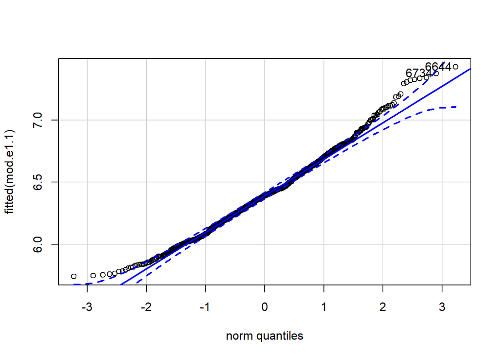

```
## 6644 6734
##  161  609
```

```r
# Let's check the residuals
qqPlot(fitted(mod.e1.1))
```

3. Participant-level differences

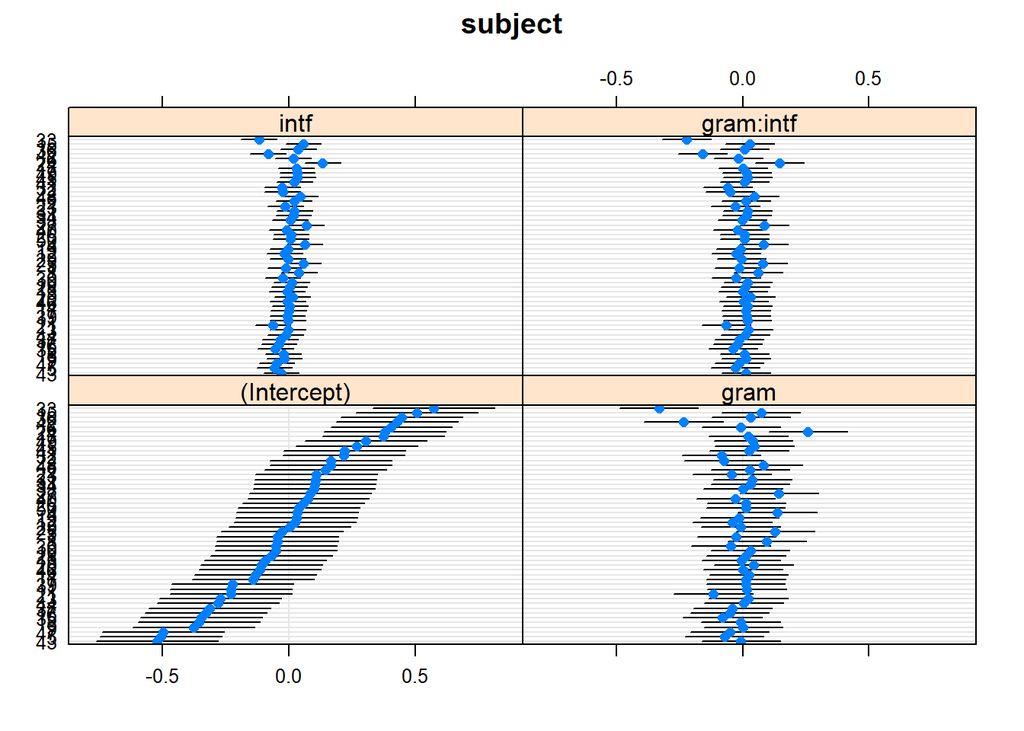

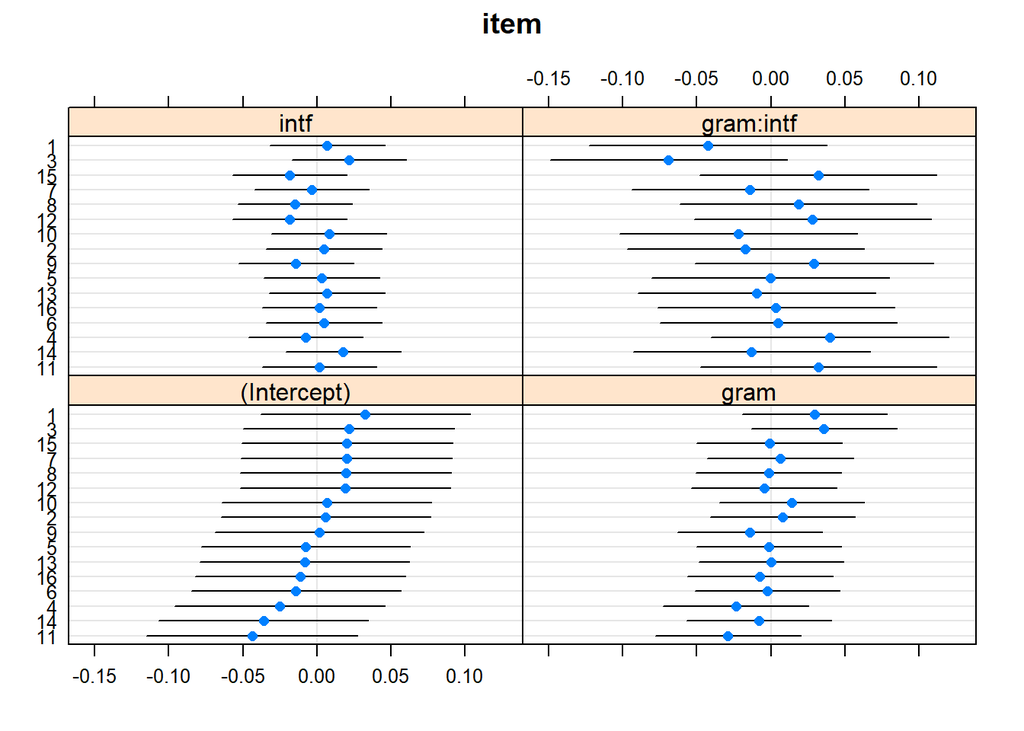

```r
print(dotplot(ranef(mod.e1.1,condVar=TRUE)))
```

#### 7.3.2 at postV1: interaction effect (grammaticality x interference)

$\textbf{Results:}$

```r
data.postV1 <- subset(data.m,roi=='postV1')
mod.e1.3 <- lmer(log(value)~gram*intf+(1+gram*intf|subject)+(1+gram*intf|item),data=data.postV1, control=lmerControl(optimizer="optimx",optCtrl=list(method='nlminb')))
#save(mod.e1.3,'models/E1_postV1_gramxintf.Rda')
```

1. Fixed effect estimates

```r
apa_table(
  as.data.frame(summary(mod.e1.3)$coefficients)
  , caption = "Estimated effect of grammaticality and interference at post V1 region"
  , escape = FALSE
)
```

(#tab:unnamed-chunk-76)

*Estimated effect of grammaticality and interference at post V1 region*

|  | Estimate | Std. Error | t value |
| --- | --- | --- | --- |
| (Intercept) | 6.07 | 0.03 | 191.78 |
| gram | 0.06 | 0.02 | 3.57 |
| intf | -0.02 | 0.02 | -0.95 |
| gram:intf | -0.03 | 0.02 | -1.41 |

**Main effect of grammaticality at postV1 region.**

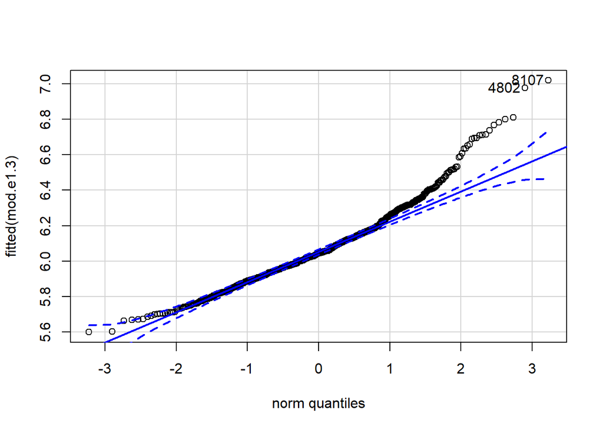

```
## 8107 4802
##  198  118
```

```r
# Let's check the residuals
qqPlot(fitted(mod.e1.3))
```

3. Participant-level differences

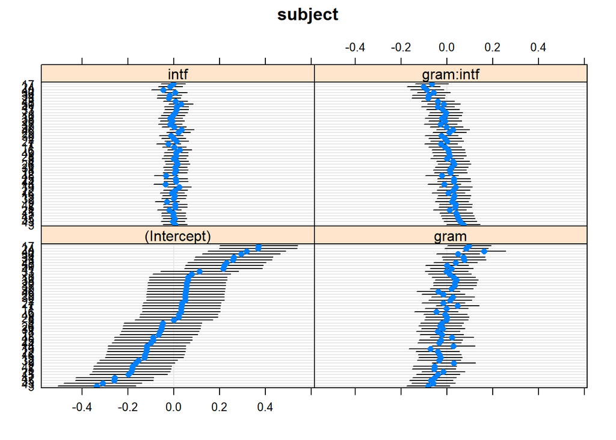

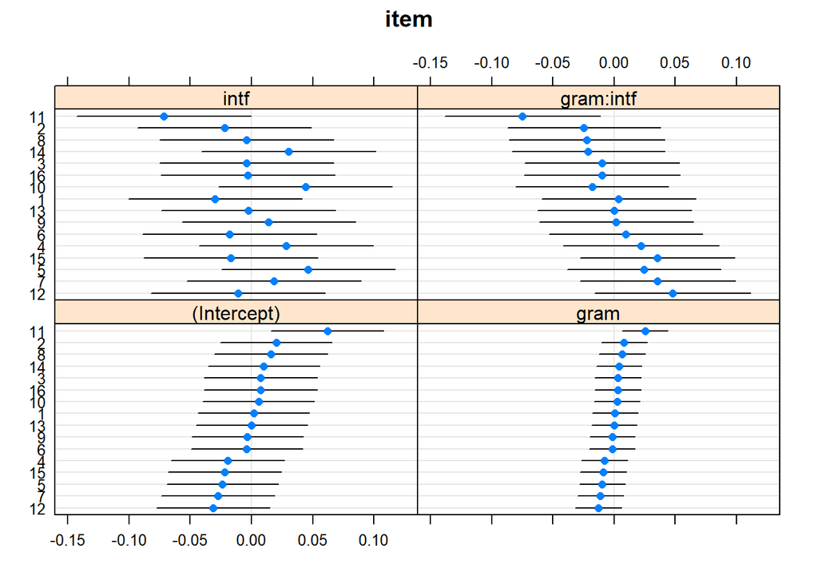

```r
print(dotplot(ranef(mod.e1.3,condVar=TRUE)))
```

### 7.4 Summary of Experiment 5

- Main effect of grammaticality at both V1 and postV1 region (evidence for VP-forgetting hypothesis).
- No interaction effect of grammaticality and interference

## 8. Experiment 6

Experiment 6 was an SPR study on English double center-embedding constructions. The items were same as experiment 5 with only difference that the relative pronoun was always *who*. Consider example (5).

1. The carpenter, who the craftsman, who the peasant carried, hurt, $supervised_{_{V1}}$ the apprentice.
2. *The carpenter, who the craftsman, who the peasant carried, – $supervised_{_{V1}}$ the apprentice.

*VP-forgetting hypothesis* predicts that Grammatical condition would have slower processing times compared to ungrammatical consition where a middle VP is missing. In particular, a slowdown is expected at V1 and postV1 in condition a compared to condition b.

### 8.1 Load the data

```
##   subject   comma expt item condition position        word measure value  roi
## 1     101 nocomma  gug    3         a        1 The_worker,      rt   358  NP1
## 2     101 nocomma  gug    3         a        2         who      rt   591 who1
## 3     101 nocomma  gug    3         a        3 the_tenant,      rt   829  NP2
## 4     101 nocomma  gug    3         a        4         who      rt   541 who2
## 5     101 nocomma  gug    3         a        5 the_foreman      rt   669  NP3
## 6     101 nocomma  gug    3         a        6 looked_for,      rt   589   V3
##   gram
## 1    1
## 2    1
## 3    1
## 4    1
## 5    1
## 6    1
```

### 8.2 Visualize the data

#### 8.2.1 Mean and Confidence interval in grammatical vs. Ungrammatical conditions

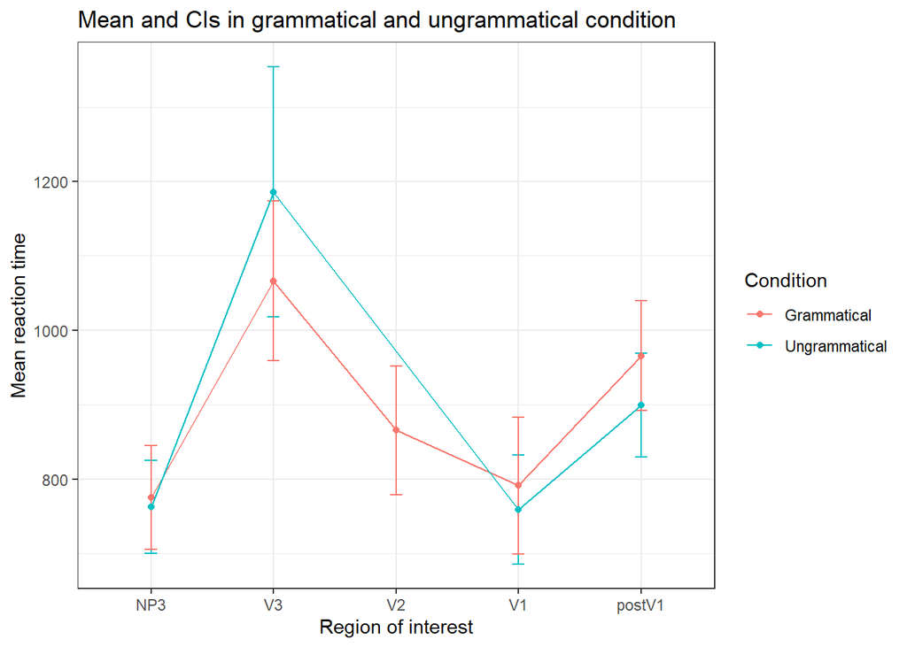

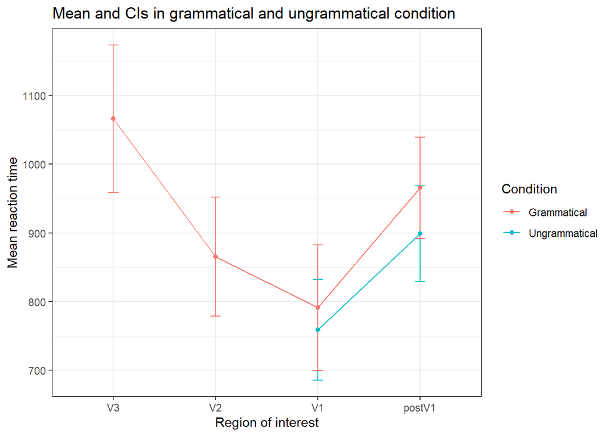

#### 8.2.2 Visualize by-subject data

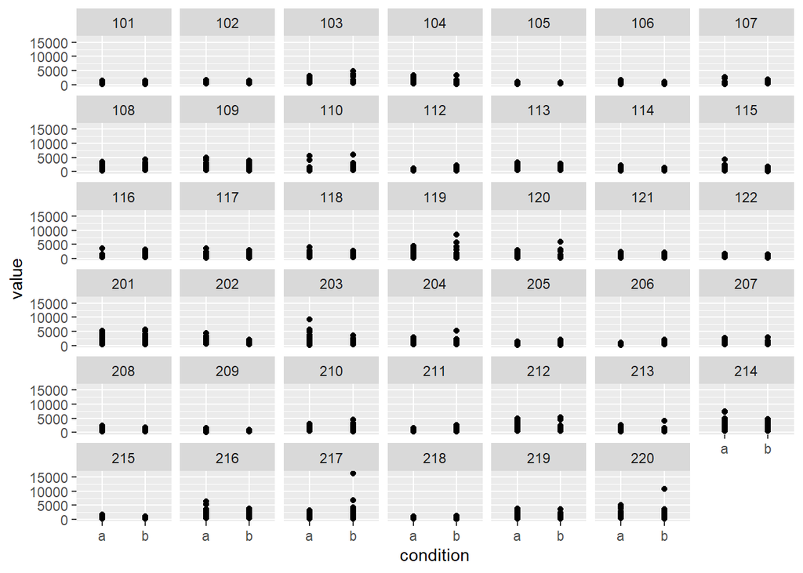

#### 8.2.3 Visualize by-item data

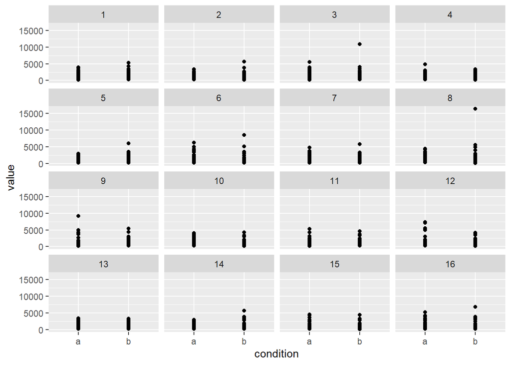

### 8.3 Analysis with linear mixed-effect models

#### 8.3.1 at V1: effect of grammaticality

$\textbf{Results:}$

```r
data.V1 <- subset(data.m,roi=='V1')
mod.e1.2 <- lmer(log(value)~gram+(1+gram|subject)+(1+gram|item),data=subset(data.V1))
```

1. Fixed effect estimates

```r
apa_table(
  as.data.frame(summary(mod.e1.2)$coefficients)
  , caption = "Estimated effect of grammaticality at V1 region"
  , escape = FALSE
)
```

(#tab:unnamed-chunk-85)

*Estimated effect of grammaticality at V1 region*

|  | Estimate | Std. Error | t value |
| --- | --- | --- | --- |
| (Intercept) | 6.45 | 0.05 | 130.58 |
| gram | 0.00 | 0.03 | -0.07 |

**No effect of grammaticality at V1**

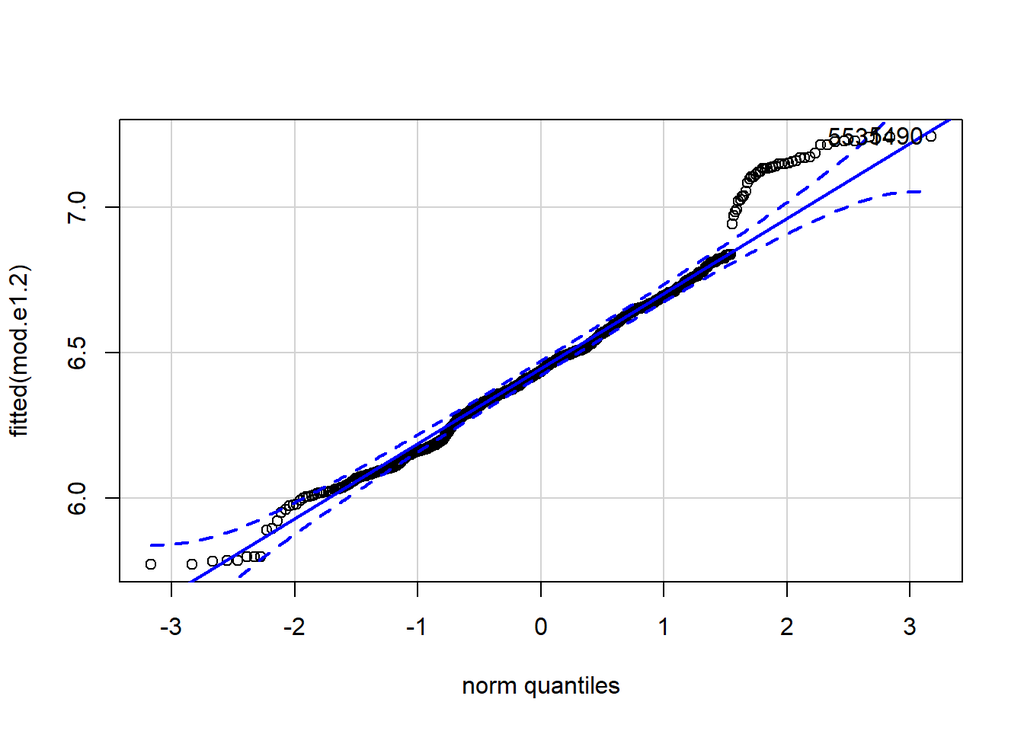

```
## 5490 5531
##  550  555
```

```r
# Let's check the residuals
qqPlot(fitted(mod.e1.2))
```

3. Participant-level differences

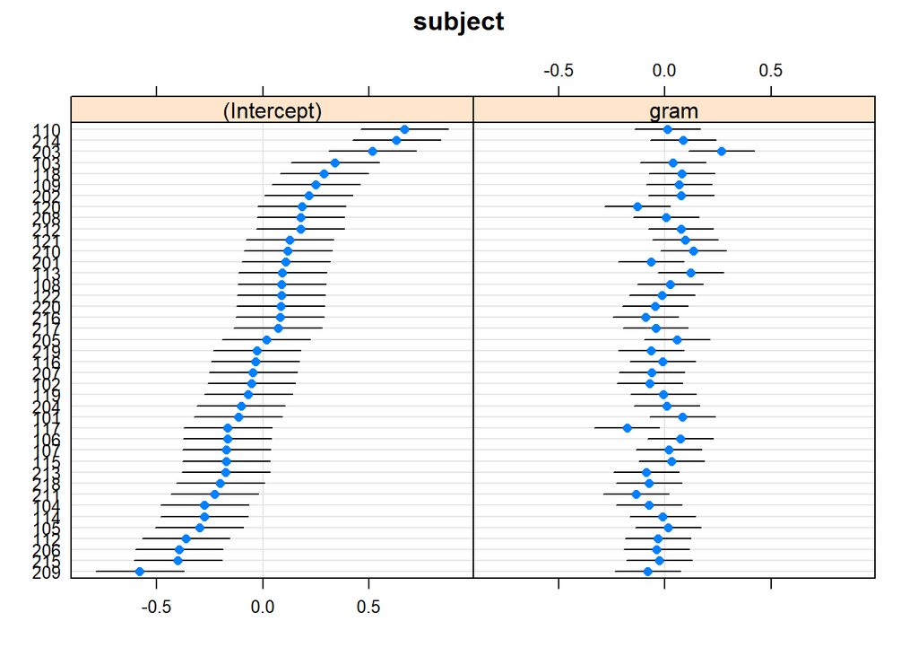

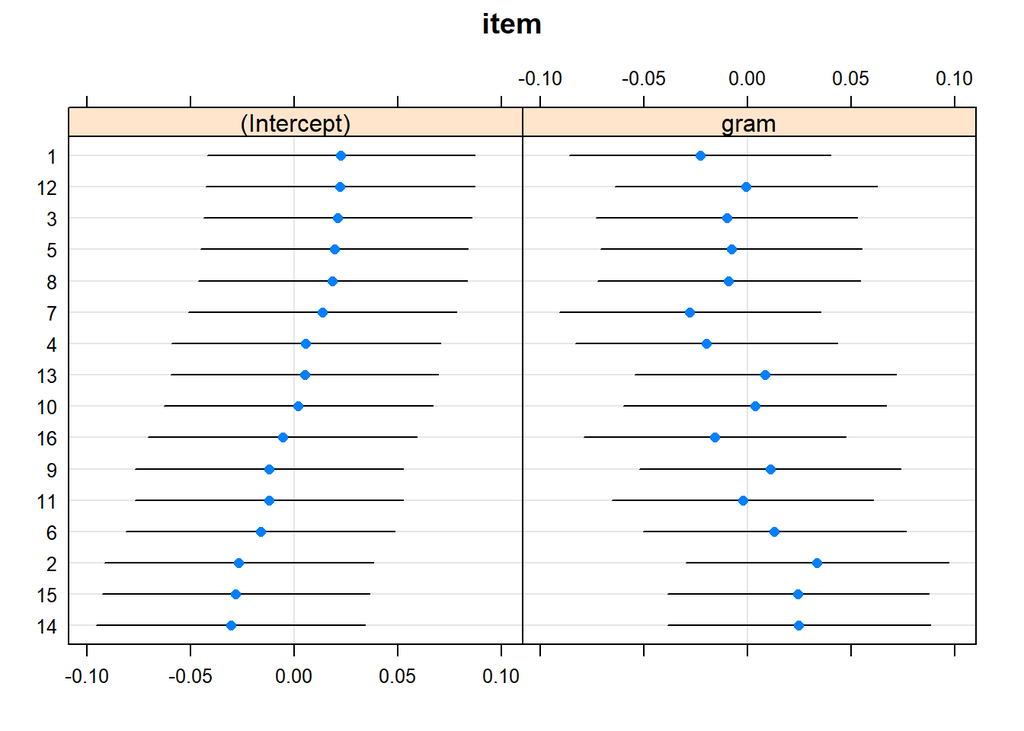

```r
print(dotplot(ranef(mod.e1.2,condVar=TRUE)))
```

#### 8.3.2 at postV1: effect of grammaticality

$\textbf{Results:}$

```r
data.postV1 <- subset(data.m,roi=='postV1')
mod.e1.4 <- lmer(log(value)~gram+(1+gram|subject)+(1+gram|item),data=subset(data.postV1))
```

1. Fixed effect estimates

```r
apa_table(
  as.data.frame(summary(mod.e1.4)$coefficients)
  , caption = "Estimated effect of grammaticality at post V1 region"
  , escape = FALSE
)
```

(#tab:unnamed-chunk-89)

*Estimated effect of grammaticality at post V1 region*

|  | Estimate | Std. Error | t value |
| --- | --- | --- | --- |
| (Intercept) | 6.66 | 0.05 | 135.18 |
| gram | 0.03 | 0.03 | 1.32 |

**No effect of grammaticality at postV1.**

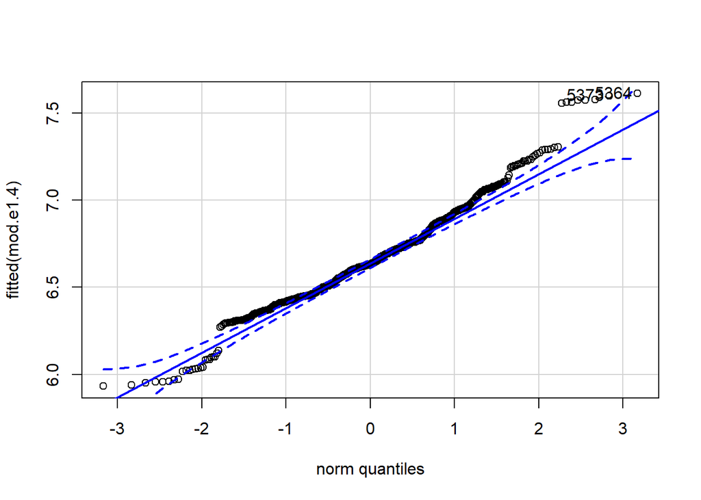

```
## 5364 5373
##  535  536
```

```r
# Let's check the residuals
qqPlot(fitted(mod.e1.4))
```

3. Participant-level differences

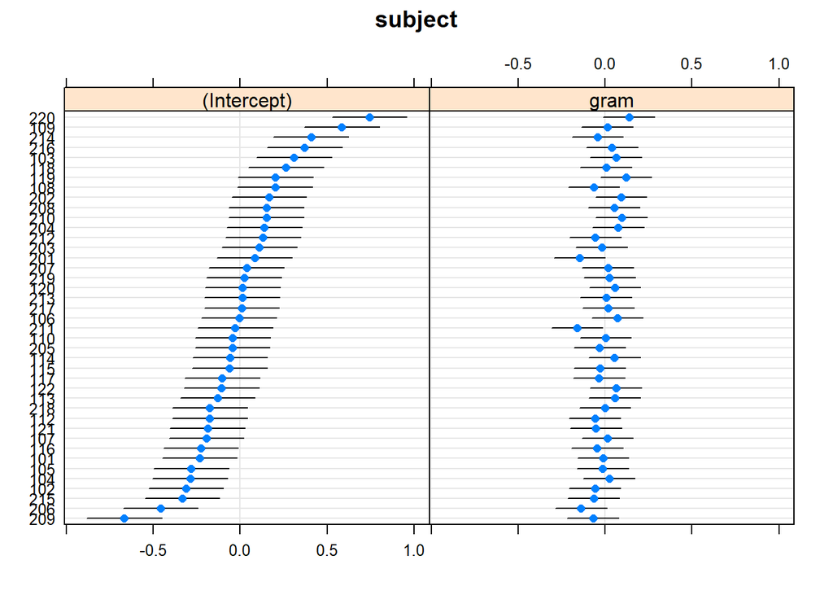

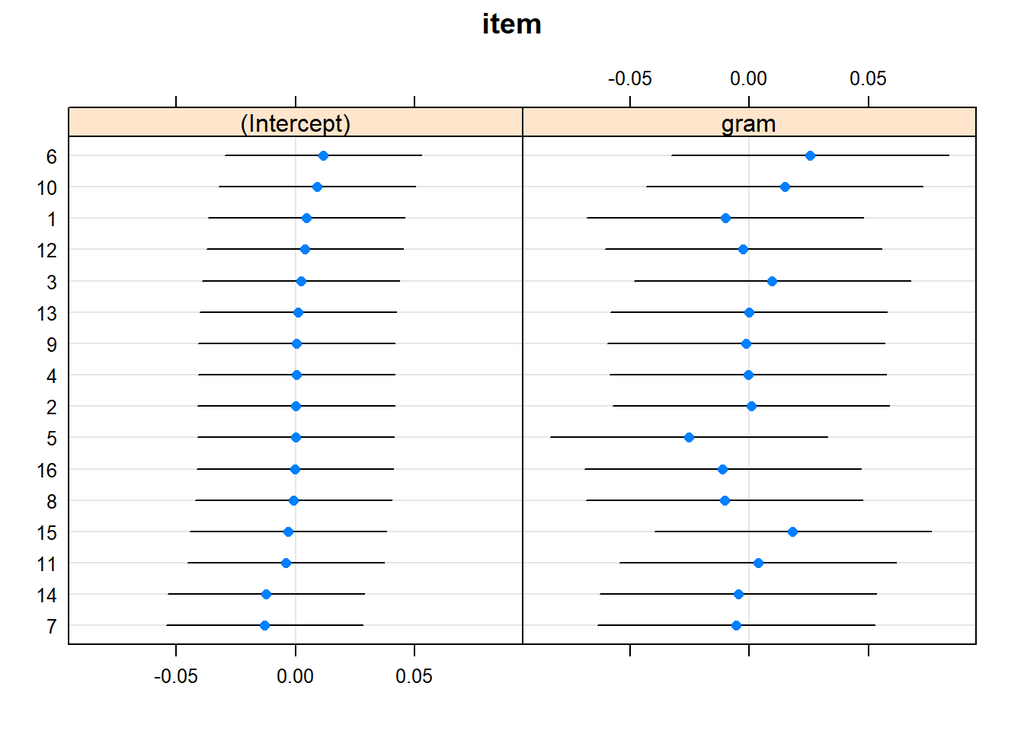

```r
print(dotplot(ranef(mod.e1.4,condVar=TRUE)))
```